# Medidas de tendencia central

[Ricardo Elian Pérez Castillo](http://Ricardopcfilos.github.io)

Taller 4 👹 2022-2, [Facultad de economía](http://www.economia.unam.mx/)

2/3/2022

### 1. ¿Qué son las medidas de tendencia central? 👺

“La **medida de tendencia central** (moda,media y mediana), **parámetro de tendencia cetral** o **medida de centralización** es un número ubicado hacia el centro de la distribución de los valores de una serie de observaciones (medidas), en la que se encuentra ubicado el conjunto de los datos. Las medidas de tendencia central más utilizadas son: media, mediana u moda. Cuando se hace referencia únicamente a la posición de estos parámetros dentro de la distribución, independientemente de que esté más o menos centrada, se habla de estas medidas como **medidas de posición**.”

[Wikipewdia(2022)](https://es.wikipedia.org/wiki/Medidas_de_tendencia_central)

```r
numeros <- sample(1:40, 100, TRUE)
numeros
```

```
##   [1] 24 19 39 16 37 25 28 37  7 22 36 32 19 32 39  7  5 28  1 18 17  3  9 32 15
##  [26] 10 35 31 30  4  6 15 21  9  8 28 34 20 39 31 30 22 10 36 39  4 18 23 19 32
##  [51]  2 31 19 19 17 37 12 19 34  6 19 21 29 33 35  6 10 23 40 33 19 32 26 23 22
##  [76] 40  2 10 13  1 40 35 16 40  9 30 28 32 21  9  6 40 30  9 39 25 34 21 35 39
```

### 2. Mediana 📍

> En el ámbito de la estadística, la **mediana** (del latín *mediānus* ‘del medio’) representa el valor de la variable de posición central en un conjunto de datos ordenados.

Wikipedia (2022)

Para obtener la **mediana**, podemos ordenar los `numeros` de menor a mayor, **el número que esté en medio de la muestra será la mediana**. Si utilizamos R, se puede hacer el cálculo de la **mediana** con la función `median`:

```r
mediana <- median(numeros)
mediana
```

```
## [1] 22.5
```

### 3. Media 🧮

“La **media** es el valor promedio de un conjunto de datos numéricos, calculada como la suma del conjunto de valores dividida entre el número total de valores.2

[Economipedia (2022)](https://economipedia.com/definiciones/media.html#:~:text=La%20media%20es%20el%20valor,matem%C3%A1tica%2C%20es%20un%20t%C3%A9rmino%20matem%C3%A1tico.)

$$Media ={\frac {1}{n}}\sum
_{i=1}^{n}a_{i}={\frac {a_{1}+a_{2}+\cdots +a_{n}}{n}}$$

Si usamos R, podemos obtener la media de una muestra si utlilizamos la función **mean**:

```r
media <- mean(numeros)
media
```

```
## [1] 22.72
```

### 4. Moda 📊

la **moda** es el valor que aparece con mayor frecuencia en un conjunto de datos.

Wikipedia (2022)

Podemos saber cuál es la **frecuencia** (número de veces que aparece un elemento en una muestra) de cada número si dibujamos un **histograma** con la función `hist`, **aquel elemento con mayor frecuencia será la moda**:

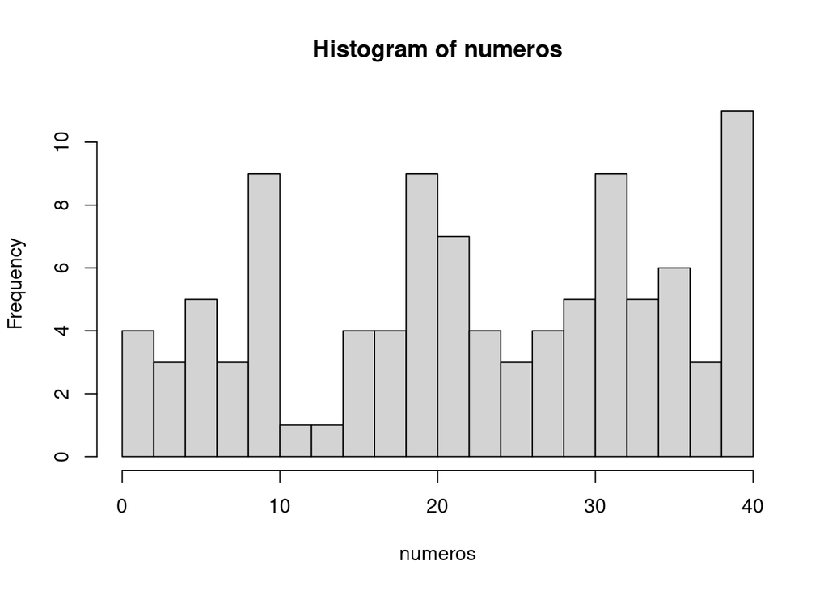

```r
# El argumento breaks nos permite dividir en histograma en las partes que queramos
hist(numeros, breaks = 20)
```

Para obtener un resultado con más precisión, podemos obtener la **moda** si generamos una **tabla de frecuencias** con la función `table` y la función `data.frame`, **aquel elemento con mayor frecuencia será la moda**:

```r
tabla.frecuencias  <-  data.frame(table(numeros))
tabla.frecuencias
```

```
##    numeros Freq
## 1        1    2
## 2        2    2
## 3        3    1
## 4        4    2
## 5        5    1
## 6        6    4
## 7        7    2
## 8        8    1
## 9        9    5
## 10      10    4
## 11      12    1
## 12      13    1
## 13      15    2
## 14      16    2
```

[output cut: 22 more lines]

### 5. Ejercicio 👩‍💻👨‍💻✍

Aplica lo que aprendiste, obten la **mediana**, **media** y **moda** de la siguiente muestra de números:

```r
# Con la función seq, creamos una secuencia de 1 a 10 en intervalos de 0.1 en 0.1
secuencia <- seq(1, 10, 0.1)
m <- sample(secuencia, 100, TRUE)
m
```

```
##   [1] 2.7 7.1 1.3 7.6 5.8 2.4 3.5 8.5 7.8 7.9 6.9 3.6 1.0 9.2 3.8 6.4 4.3 7.5
##  [19] 6.4 4.5 3.3 1.7 9.2 6.8 5.5 2.0 4.6 7.2 9.0 2.0 1.6 5.0 4.8 6.1 9.2 1.0
##  [37] 7.2 1.3 4.7 1.1 1.1 3.4 6.8 4.4 7.3 5.8 4.0 9.8 1.4 3.8 3.3 6.8 1.4 7.8
##  [55] 2.8 9.1 9.5 2.3 2.2 2.5 5.2 4.3 5.1 7.3 6.3 1.5 3.6 3.8 7.8 4.9 2.5 8.6
##  [73] 4.3 6.2 2.7 7.9 5.1 3.4 3.7 5.9 4.2 5.0 5.8 4.0 5.8 7.8 2.1 4.3 4.6 3.1
##  [91] 7.6 1.0 8.2 8.3 2.4 1.0 6.3 6.7 7.3 2.3
```

##### Mediana

```r
# Aquí el cálculo de la mediana
mediana.m <- median(m)
mediana.m
```

```
## [1] 4.75
```

##### Media

```r
# Aquí el cálculo de la media
media.m <-mean(m)
media.m
```

```
## [1] 4.949
```

##### Moda

```r
# Aquí el cálculo de la moda
moda.m <-  data.frame(table(m))
moda.m
```

```
##      m Freq
## 1    1    4
## 2  1.1    2
## 3  1.3    2
## 4  1.4    2
## 5  1.5    1
## 6  1.6    1
## 7  1.7    1
## 8    2    2
## 9  2.1    1
## 10 2.2    1
## 11 2.3    2
## 12 2.4    2
## 13 2.5    2
## 14 2.7    2
```

[output cut: 46 more lines]

💻[Código disponible en RStudio Cloud](https://rstudio.cloud/project/3671022)💻